# What are the most valuable spots to shoot from?

Why we observe a ‘lay it up’ or ‘trey it up’ league.

Author

Louis BT

Published

March 31, 2025

**Code: Setup**

```r
library(tidyverse)
library(ggplot2)
library(gridExtra)
library(kableExtra)
library(caret)
library(patchwork)
library(viridis)
library(grid)
library(cowplot)
source('half.court/half_court_plot_w_corner.R')

advdata = read.csv('advanced.csv')
data = read.csv('2024.csv')
pbpdata = read.csv('2024pbpclean.csv')
```

### Introduction

In the past 10 years, the average 3-point field goal attempts increased from 22.4 (2014-15) to 35.1 (2023-24). The three-point revolution began with Steph Curry leading the Golden State Warriors to their 2015 title. The rest of the league followed Golden States’ lead, realising that 3 was indeed 1.5 times more than 2.

### Graph

**Code: Data Manipulation**

```r
df = data %>%
  select(c("team", "date", "fgm", "fga", "X3pm", "X3pa", "ftm", "fta", "fgm_.5", "fga_.5", "fgm_5.9", "fga_5.9", "fgm_10.14", "fga_10.14", "fgm_15.19", "fga_15.19", "fgm_20.24", "fga_20.24", "fgm_25.29", "fga_25.29", "fgm_L_cor3", "fga_L_cor3", "fgm_R_cor3", "fga_R_cor3", "fgm_ab3", "fga_ab3" )) %>%
  mutate(date = as.Date(date)) %>%
  group_by(team, date) %>%
  mutate(across(
    .cols = everything(),
    .fns = ~ as.numeric(gsub('-', '0', .))
  )) %>% summarise(across(where(is.numeric), sum)) %>%
  mutate(across(.cols = everything(), .fns = ~ replace_na(.x, 0))) %>%
  select(team, date, X3pm, X3pa, "fgm_L_cor3", "fga_L_cor3", "fgm_R_cor3", "fga_R_cor3", "fgm_ab3", "fga_ab3")
# glimpse(df)

pbpdf = pbpdata %>%
  select(date, team, shot_type, shot_distance, `X2fgm`, `X2fga`, `X3fgm`, `X3fga`) %>%
  filter(!is.na(shot_distance)) %>%
  mutate(
    date = as.Date(date, "%d/%m/%Y"),

    `fgm_.5` = ifelse((shot_distance < 5) & (`X2fgm` == 1), 1, NA),
    `fga_.5` = ifelse((shot_distance < 5) & (`X2fga` == 1), 1, NA),
    `fgm_5.10` = ifelse((shot_distance >= 5 & shot_distance < 10) & (X2fgm == 1), 1, NA),
    `fga_5.10` = ifelse((shot_distance >= 5 & shot_distance < 10) & (X2fga == 1), 1, NA),
    `fgm_10.15` = ifelse((shot_distance >= 10 & shot_distance < 15) & (X2fgm == 1), 1, NA),
    `fga_10.15` = ifelse((shot_distance >= 10 & shot_distance < 15) & (X2fga == 1), 1, NA),
    `fgm_15.20` = ifelse((shot_distance >= 15 & shot_distance < 20) & (X2fgm == 1), 1, NA),
    `fga_15.20` = ifelse((shot_distance >= 15 & shot_distance < 20) & (X2fga == 1), 1, NA),
    `fgm_20.3` = ifelse((shot_distance >= 20) & (X2fgm == 1), 1, NA),
    `fga_20.3` = ifelse((shot_distance >= 20) & (X2fga == 1), 1, NA),
    fgm = ifelse((`X2fgm` == 1) | (`X3fgm` == 1) , 1, NA),
    fga = ifelse((`X2fga` == 1) | (`X3fga` == 1), 1, NA),
    X3fgm = ifelse((`X3fgm` == 1), 1, NA),
    X3fga = ifelse((`X3fga` == 1), 1, NA),

    heave_m = ifelse((shot_distance >= 40) & (X3fgm == 1), 1, NA),
    heave_a = ifelse((shot_distance >= 40) & (X3fga == 1), 1, NA)
  ) %>%
  select(!c(shot_type,shot_distance, `X2fgm`, `X2fga`, `X3fgm`, `X3fga`)) %>%
  group_by(team, date) %>%
  mutate(across(.cols = everything(), .fns = ~ replace_na(., 0))) %>%
  summarise(across(.cols = everything(), sum))
# view(pbpdf)

comb.df = df %>%
  left_join(
    y = pbpdf,
    by = c("date", "team" )
  ) %>%
  filter(abs(X3pa - fga_L_cor3 - fga_R_cor3 - fga_ab3 - heave_a) <= 1) %>% ungroup() %>%
  select(!c(date, team)) %>%
  summarise(across(where(is.numeric), sum)) %>%
  mutate(

  efg = (fgm + 0.5 * X3pm) / fga,

  # Field Goal Percentage by Distance
  `<5ft%` = `fgm_.5` / `fga_.5`,
  `[5,10)%` = `fgm_5.10` / `fga_5.10`,
  `[10,15)%` = `fgm_10.15` / `fga_10.15`,
  `[15,20)%` = `fgm_15.20` / `fga_15.20`,
  `[20,3)%` = `fgm_20.3` / `fga_20.3`,
  `Lcor3%` = 1.5*fgm_L_cor3 / fga_L_cor3,
  `Rcor3%` = 1.5*fgm_R_cor3 / fga_R_cor3,
  `ab3%` = 1.5*`fgm_ab3` / `fga_ab3`,
  `heave%` = heave_m / heave_a,

  # Weight
  `<5ft_weight` = `fga_.5` / fga,
  `[5,10)_weight` = `fga_5.10` / fga,
  `[10,15)_weight` = `fga_10.15` / fga,
  `[15,20)_weight` = `fga_15.20` / fga,
  `[20,3)_weight` = `fga_20.3` / fga,
  `L_cor3_weight` = `fga_L_cor3` / fga,
  `R_cor3_weight` =  `fga_R_cor3`/fga,
  `ab3_weight` =  `fga_ab3` / fga,
  `heave_weight` = heave_a / fga
  ) %>%
  select(!c(X3pm, X3pa, fgm_L_cor3, fga_L_cor3, fgm_R_cor3, fga_R_cor3, fgm_ab3, fga_ab3, fgm_.5, fga_.5, fgm_5.10, fga_5.10, fgm_10.15, fga_10.15, fgm_15.20, fga_15.20, fgm_20.3, fga_20.3, fgm, fga, heave_m, heave_a))
# view(comb.df)
```

**Graph Explanation:**

**Code: Graph Creation**

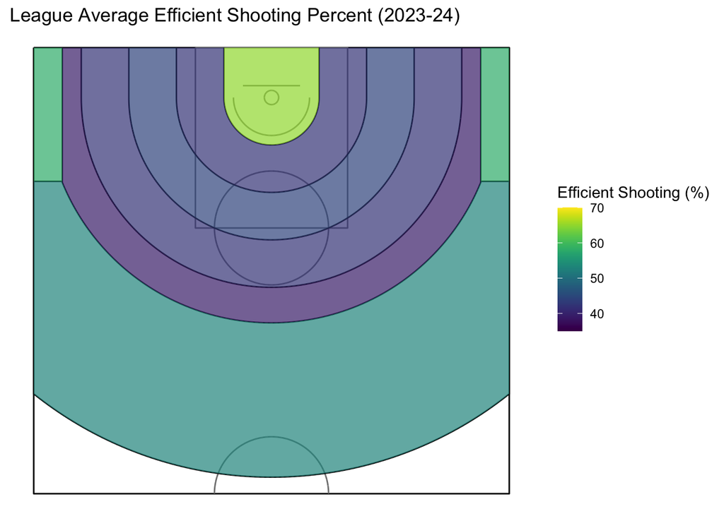

```r
# glimpse(comb.df)
pct = as.vector(comb.df %>% select(`<5ft%`:`ab3%`)) %>% unlist() %>% as.numeric() * 100
wgh = as.vector(comb.df %>% select(`<5ft_weight`:`ab3_weight`)) %>% unlist() %>% as.numeric() * 100

lowest_value_base5 = floor(min(pct)/5) *5
highest_value_base5 = ceiling(max(pct)/5) * 5
diff_base5 = highest_value_base5 - lowest_value_base5 + 1
no_colour = rep(NA, times= lowest_value_base5-1)
palette = c(no_colour, viridis(diff_base5, option = 'viridis'))

pct_mapped = c("", "", palette[pct])
pct.plot = create_plot(colours = pct_mapped, title = 'League Average Efficient Shooting Percent (2023-24)')

{
  dummy.df <- data.frame(
  val = seq(lowest_value_base5, highest_value_base5, length.out = 100)
)
legend.p <- ggplot(dummy.df, aes(x = val, y = 1, color = val)) +
  geom_point(size = 4) +
  scale_color_gradientn(
    colors = viridis(diff_base5, option = 'viridis'),
    limits = c(lowest_value_base5, highest_value_base5),
    name = "Efficient Shooting (%)"
  ) +
  theme_minimal()
  legend_grob <- get_legend(legend.p)
}

grid.arrange(pct.plot, legend_grob, ncol = 2, widths = c(0.75, 0.25))
```

**Code: Graph Creation**

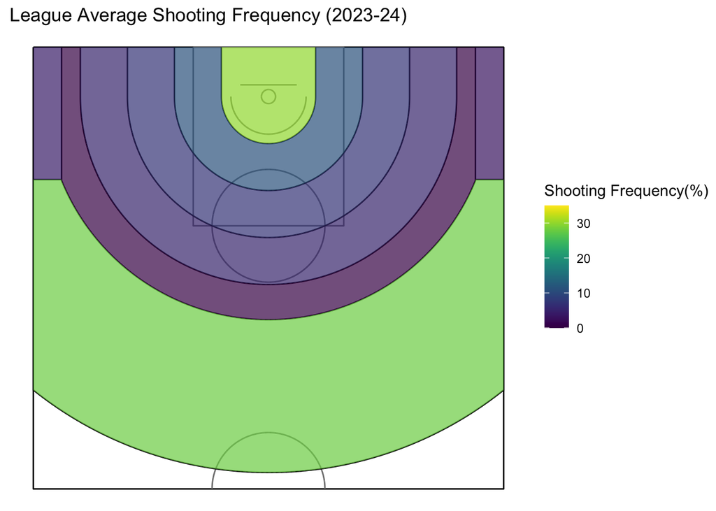

```r
lowest_value_base5 = floor(min(wgh)/5) *5
highest_value_base5 = ceiling(max(wgh)/5) * 5
diff_base5 = highest_value_base5 - lowest_value_base5 + 1
no_colour = rep(NA, times= lowest_value_base5)
palette = c(no_colour, viridis(diff_base5, option = 'viridis'))

wgh_mapped = c("", "", palette[wgh])

wgh.plot = create_plot(colours = wgh_mapped, title = 'League Average Shooting Frequency (2023-24)')
{
  dummy.df <- data.frame(
  val = seq(lowest_value_base5, highest_value_base5, length.out = 100)
)
legend.p <- ggplot(dummy.df, aes(x = val, y = 1, color = val)) +
  geom_point(size = 4) +
  scale_color_gradientn(
    colors = viridis(diff_base5, option = 'viridis'),
    limits = c(lowest_value_base5, highest_value_base5),
    name = "Shooting Frequency(%)"
  ) +
  theme_minimal()
  legend_grob <- get_legend(legend.p)
}

grid.arrange(wgh.plot, legend_grob, ncol = 2, widths = c(0.75, 0.25))
```

Quite simply, when accounting for the fact that three-point shots are worth more than two-point shots. The most valuable shots are within five feet of the rim, and the corner three-point shots. It is astonishing the see how much worse-off shooting a mid-range two-point shot is than a three, and how fast the fall off in percent is when moving slightly away from the rim.

### Limitations

There are many limitations to perceiving basketball like this:

- **Foul-Rate**: While I do not possess the data for where shooting fouls are drawn, most shooting fouls are drawn closer to the rim. The value of the potential to shoot more free-throws is not part of this report. It may under examination later on when I look at what teams draw the most fouls, and where they shoot most of their shoots from.
- **Offensive Rebounding**: The closer you are to the rim, the more likely you are to get the offensive rebound. The graph does not account this advantage.
- **Diversification**: It should be noted that in a game a single playstyle is easier to defend (especially in the playoffs). A team with players that are a threat from all over the court is (in my opinion) the most important. The graph only represents how well the league shoots from different locations, and why we observe a three’s and layup’s league.

### Concluding Remarks

I hope this graph clearly demonstrates why teams emphasize shooting layups and three-point shots. Shooting mid to long range two-point shots is on average 15-20% less valuable.